# Executive-Case-Summary-Module-3---Team-8

## **House Price Case Study Project**

#### **(Executive Case Summary)**

#### Ammon Wilson

**Title Page 1**

**Background 2**

**Methodology 3**

**Discussion Responses 4**

## **Background**

The study intends to predict house pricing and provide quantifiable evidence that our predictions are reliable by studying the factors influencing the price, such as date, bedrooms, etc. Its purpose is to research and learn about the housing market’s trends and correlations to meet the interests of our customers.

We ran models such as linear regression, Random Forest Regression, and XGBoost Regression. However, we decided to keep XGBoost because it can handle missing values accurately, is adaptable to uncorrelated data, and isn’t too biased towards one feature or influence in the data to skew the results. Furthermore, we compared the results to metrics such as “Mean Absolute Error,” which simply displays how far the predictions are from the actual target on average. To test the magnitude error of the predictions, we tuned the model to be more accurate and not give estimates too high on unfavorable neighborhoods.

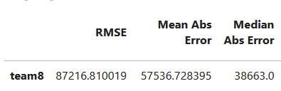

Quantifying our results using metrics such as “Mean Absolute Error” resulted in a score of $57,536.73, implying that our predictions were only off from the actual result by $57,536.73 on average. We also used metrics such as “Median Absolute Error,” with a score of “38663.0”, which takes the median of the results instead of the mean, thus yielding a result less sensitive to predictions that are very far from the target. In this case, our predictions are $38,663.0 away from the target on a median scale. As well as “RMSE(Root mean square error,”, which serves as a measure that emphasizes big mistakes by encouraging the model to reduce smaller errors.

## **Methodology**

We split the data with 20% of the values designed for the test, then trained the model with the other 80% of the data to predict the values in the test. Furthermore, we’ve tuned the model by testing different parameters/settings on the model to yield more accurate results. For example, we’ve implemented the “Root Mean Squared Error” as the metric due to the request not to overestimate houses that could be in the low-income bracket. It was followed by a moderate learning rate value that reduces the chances of inaccurate and inconsistent solutions/predictions. As well as modifying the subsample/data distributed to the model’s mini-training rounds reduces bias in memorizing the training data instead of making predictions of the test data. After the test, the model evaluated the results and displayed the most important features to properly and confidently predict the correct housing prices.

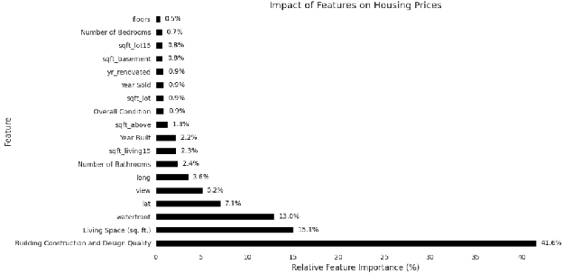

As shown in the graph above, the model found that “Building & Design” or grade rating, along with square feet of living space and view were among the biggest contributors to the predictions. In other words, the stated features are the biggest factors contributing to correctly predicting house prices. Thus, we now have quantifiable evidence from correlations and result metrics to identify properties in low-income areas for the interest of our customers. Therefore, we can confidently suggest identifying properties based on luxury features such as Design quality, waterfront, living space, and view for the case study.

## **Discussion Responses**

### **1. Problem Type**

This is a **supervised regression problem,** which is based on structured data features, we predict a continuous variable (**house price**). The target variable is continuous which fits the regression criteria. We trained the model using historical housing data with labeled outcomes.

### **2. Model Confidence**

To quantify prediction reliability, we used multiple metrics:

- **R² Score:** 0.9069 (indicating strong model fit)
- **MAE:** $57,536 (average deviation from actual price)
- **RMSE:** $87,216 (measuring spread of errors)
- **Median Absolute Error:** $38,663 (indicating half of the predictions are within this margin)
- **Prediction Intervals:** The majority of our predictions fall within 20% of actual values.

**Selected Metric:**

- **D. The R² value** is the best measure of model confidence because it indicates how well the model explains the variability in home prices. A high R² value of **0.9069** suggests the model captures most of the underlying patterns in the data.

These metrics collectively provide **empirical confidence** in the model’s performance, illustrating the model’s capability to produce reliable predictions.

### **3. Insurance Concerns & Ethical Considerations**

William (VP of Finance) raised concerns about adjusting home values for lower-income neighborhoods. After careful consideration, we strongly **advise against manual price reductions**, as this practice may violate **Fair Housing laws**. Instead, we propose:

- **Incorporating additional socio-economic features** (Option B), such as local **crime rates, school ratings, and average income**, allows the model to make unbiased, data-driven predictions.
- **Ensuring ethical AI practices**, and avoiding discrimination in pricing recommendations.
- **Training the model on comprehensive, representative datasets** to reduce potential biases.

**Explanation:**

- **Option B** was chosen because adding external demographic data can help the model **recognize patterns in pricing** without directly applying arbitrary adjustments to predictions. Actions like those in **Options A or C** risk introducing bias, while **Option D** highlights the potential legal risks of manual adjustments.

### **4. Feature Scaling & Data Handling**

Johnny (Data Science Intern) asked about feature scaling. Since **XGBoost automatically handles different** **feature scales**, no additional normalization was needed. However, standardization would be required for models like linear regression.

Additionally, we ensured that **categorical features were appropriately encoded** and **irrelevant columns** (like ‘id’) were removed to enhance model performance.

##### **Python Notebooks:**

Below are Github Gist links to the notebooks we used during this case study:

- https://github.com/ryjason/CalculatorApp/blob/3fdd45fca4f2f0f684bf78c09b45541182b8688c/notebooks/module03_housing_grading_mini.ipynb
- https://github.com/ryjason/CalculatorApp/blob/a2d443558332bf043ae98e88cdf45da6e12b3e94/notebooks/starter_housing.ipynb